# Power and sample size calculations correlational studies

Wenying Gu

11/25/2019

### Email: wenying.gu@vanderbilt.edu

# Situation Simulation

A common research objective is to demonstrate that two measurements are highly correlated. One measurement, call it A, may reflect the severity of disease but is difficult or costly to collect. Another measurement, call it B, may be easier to collect and potentially related to measurement A. If there is strong association between A and B, a cost effective strategy for diagnosis may be to collect measurement B instead of A.

In this deliverable, I will perform a power and sample size calculation for a collaborator who is submitting a grant application to fund a study to show that two measurements are highly correlated. Reviewers of the grant want to fund studies that have a high likelihood of success, which in this setting is conclusively demonstrating that the correlation between A and B is greater than 0.8.

The researcher will collect both measurements on N individuals. The analysis will proceed by calculating a one-sided confidence interval. If the confidence interval is completely within the range from 0.8 to 1, then the researcher will consider the study to be a success: A conclusive demonstration that the correlation between A and B is greater than 0.8.

Power is the probability that the study will end in success when the true underlying correlation is, in fact, greater that 0.8. (Note the connection to Type II error (β): power = 1 - β.) Here I estimate power for different combinations of sample size and the true population correlation. Let the sample size be 25, 50, 75, and 100. Let the population correlation range from 0.8 to 0.95.

# Load package

In this study, mvtnorm; tidyverse and ggolot2 have been introduced.

```r
suppressPackageStartupMessages(require(mvtnorm))
library(tidyverse)
library(ggplot2)
```

# Generate a function to catch power

By using the cor.test function, the power that is conclusive demonstration will be collected. They are the correlations between A and B greater than 0.8.

```r
corr_study<-function(df_N_rho){
N <- df_N_rho$N
rho <-df_N_rho$rho
null_correlation <- 0.8
R <- 5000

sigma<- array(c(1,rho,rho,1), c(2,2))
mu <- c(0,0)

detect <- rep(NA, R)
for(i in 1:R){
  data <- rmvnorm(N, mean = mu, sigma = sigma)
  results <- cor.test(x = data[,1], y = data[,2], alternative = "greater")
  detect[i] <- results$conf.int[1] > null_correlation
}
power <- mean(detect)
df<-data.frame(N=N,rho=rho,power=power)
}
```

# Set up the N and rho

Let the sample size be 25, 50, 75, and 100. Let the population correlation range from 0.8 to 0.95.

```r
set_up<-expand.grid(N=c(25,50,75,100),rho=seq(0.8,0.95,0.01))
```

# Mapping the data into generated function

This chunk mapped the set up data into the generated function to get a complete dataframe for graphying.

```r
new_df<-set_up%>%
  split(seq(nrow(.))) %>%
  map(corr_study) %>%
  do.call(rbind,.)
```

# Graph

Here is the graph for displaying.

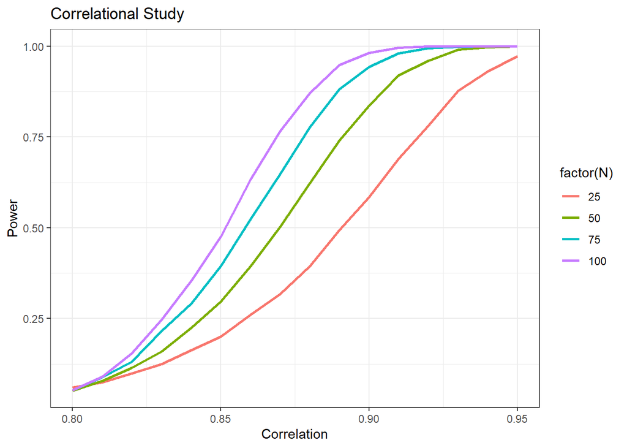

```r
ggplot(new_df,aes(x=rho,y=power,col=factor(N),group=N))+
  geom_line(size=1)+
  labs(title="Correlational Study", x="Correlation", y="Power")+
  theme_bw()
```